# EVscope Comprehensive RNA-seq Analysis Report

EVscope Example

Anonymized example

Anonymized example report | Sample: Example_001. Names, project/sample identifiers, run dates/times, and private filesystem paths have been removed or replaced, including embedded subreports and figure labels. Original analysis values are retained; this is an identifier-redacted example, not a synthetic dataset.

# EVscope Pipeline Overview

**EVscope** is an open-source, kit-aware bioinformatics pipeline for EV-enriched RNA sequencing generated with either the SMARTer Stranded Total RNA-Seq Kit or the SMARTer smRNA-seq Kit. The active library profile is selected through EVscope_KIT. Kit-aware preprocessing applies the appropriate library-structure and adapter handling: UMI extraction, UMI read-through trimming, and UMI-based deduplication are used only for the Total RNA profile, while the smRNA profile follows a no-UMI-deduplication workflow. EVscope includes EMapper, a two-round expectation-maximization (EM) module: Round 1 resolves positional ambiguity using alignment scores and local coverage evidence, and Round 2 resolves gene-level ambiguity for overlapping annotations using abundance-based weights with effective-length normalization. EMapper generates EM-weighted genome-coordinate BigWig coverage tracks at single-base or binned resolution, with strand-aware outputs and RNA annotation support for downstream genome-browser inspection, RNA-biotype density plots, and meta-gene coverage profiling. The workflow integrates quality control, library-structure analysis, contamination assessment, read alignment, feature/RNA annotation, expression matrix generation, optional genomic DNA sensitivity summaries, exploratory source-enrichment analysis, and visualization in a comprehensive HTML report.

**Selected library kit:** SMARTer smRNA-seq Kit

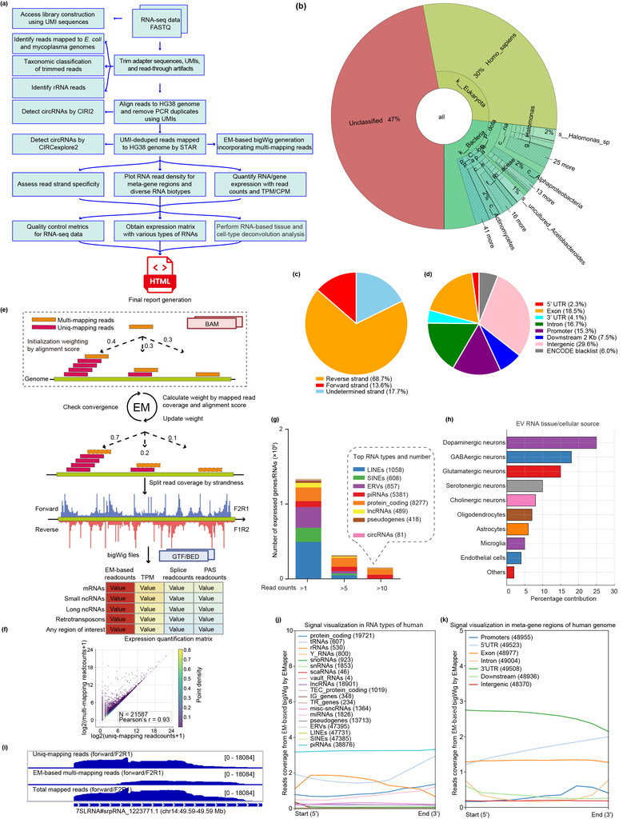

Figure: EVscope Pipeline Architecture

# Step 01: Raw Data QC

#### FastQC Report - Read 1

[interactive chart not shown]

#### FastQC Report - Read 2

[interactive chart not shown]

# Step 02: Library Structure Analysis

#### SMARTer smRNA-seq Library Profile

| Parameter | Value |
| --- | --- |
| Kit | SMARTer smRNA-Seq Kit for Illumina |
| Input layout | Paired-end Read 1 / Read 2 |
| Read orientation | Sense |
| UMI | No |
| R1 structure | 3-nt template-switch sequence + RNA insert + poly(A) |
| 5-prime fixed trim | 3 nt |
| 3-prime adapter | AAAAAAAAAA |
| R2 structure | 14-nt poly(T) + reverse-complement RNA insert + 3-nt template-switch sequence + Illumina adapter |
| R2 5-prime fixed trim | 14 nt |
| R2 3-prime adapter | NNNAGATCGGAAGAGC |

[output cut: 2 more lines]

# Step 03: Library Preprocessing and Adapter Trimming

#### Read Length Distribution After Trimming

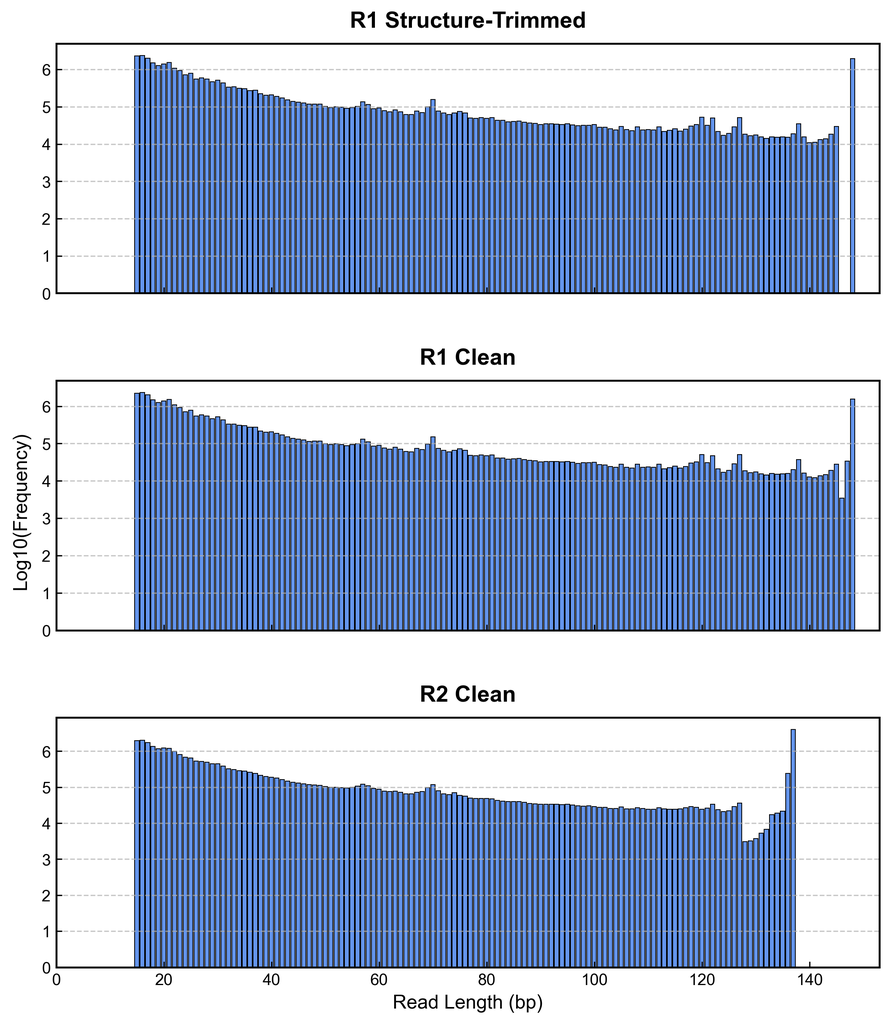

# Step 04: Trimmed Data QC

#### Trimmed FastQC Report - Read 1

[interactive chart not shown]

#### Trimmed FastQC Report - Read 2

[interactive chart not shown]

# Step 06: Initial Alignment

#### STAR Initial Alignment Summary

| Metric | Value |
| --- | --- |
| Started job on | [time withheld] |
| Started mapping on | [time withheld] |
| Finished on | [time withheld] |
| Mapping speed, Million of reads per hour | 629.51 |
| Number of input reads | 28327881 |
| Average input read length | 87 |
| Uniquely mapped reads number | 1340678 |
| Uniquely mapped reads % | 4.73% |
| Average mapped length | 55.55 |
| Number of splices: Total | 64744 |

[output cut: 22 more lines]

# Step 06: Refined Alignment

#### STAR Refined Alignment Summary (No UMI Deduplication)

| Metric | Value |
| --- | --- |
| Started job on | [time withheld] |
| Started mapping on | [time withheld] |
| Finished on | [time withheld] |
| Mapping speed, Million of reads per hour | 633.42 |
| Number of input reads | 28327881 |
| Average input read length | 87 |
| Uniquely mapped reads number | 1340678 |
| Uniquely mapped reads % | 4.73% |
| Average mapped length | 55.55 |
| Number of splices: Total | 64744 |

[output cut: 22 more lines]

# Step 07: Strand Detection

This module evaluates library strand assignment and splice-junction evidence for strand-aware EV RNA-seq quality control.

Strandness overview

Overall strandness summary

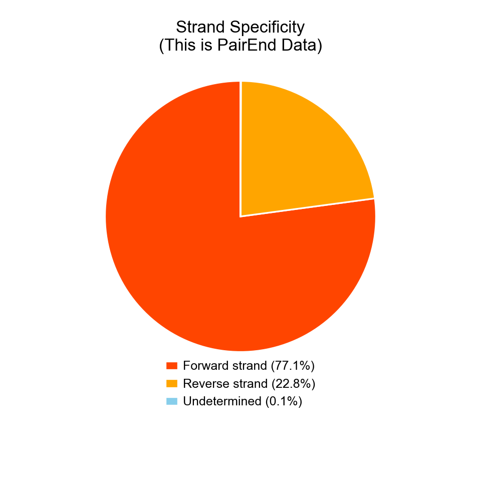

Strand assignment by aligned query length

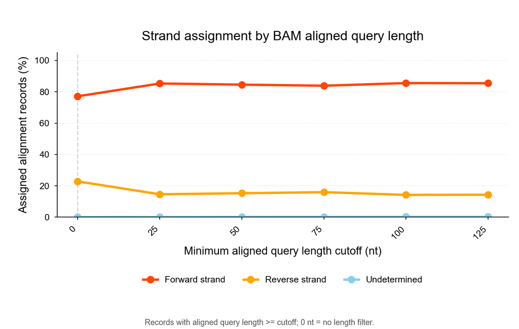

Points show strand assignment among eligible alignment records after applying minimum aligned-query-length cutoffs. The 0-nt point represents the result without aligned-length filtering. Paired-end mates are counted as separate alignment records.

Splice junction evidence

**Splice junction density:** 0.87 SJ/kb - normalized by uniquely mapped aligned sequence.

Splice junction density (SJ/kb)

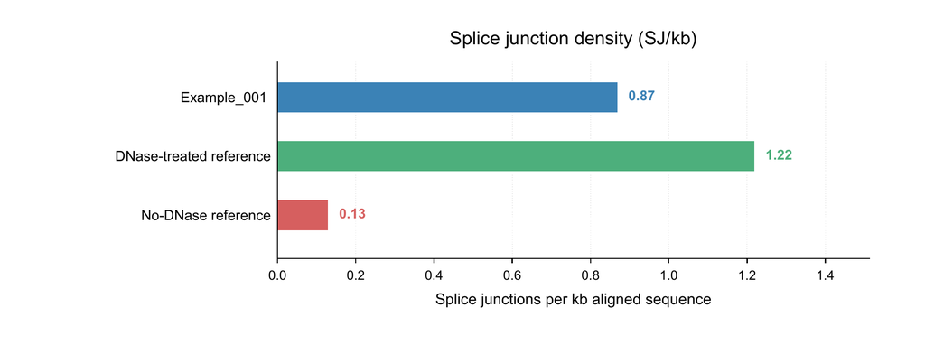

**How this metric is calculated**

SJ/kb = total splice junction crossings per kb of uniquely mapped aligned sequence. A higher value indicates more splice-junction evidence per aligned sequence length. This is supportive evidence for spliced RNA content, not a standalone pass/fail metric.

For paired-end STAR logs, the denominator uses both mates’ uniquely mapped aligned bases per fragment/read-pair, not insert size. Pilot reference samples are contextual benchmarks rather than fixed diagnostic thresholds: single no-DNase control splice/kb = 0.13; TURBO DNase pilot libraries = 1.67 (0.5 U, 10 min), 0.63 (0.25 U, 10 min), 1.64 (0.5 U, 5 min), and 0.94 (0.25 U, 5 min).

Raw metrics

**Original strandedness table**

Original Step 07 strandness output used for the overall strandness summary.

Total 1 rows from Example_001_STAR_no_dedup_Aligned.sortedByCoord.out_bam2strandness.tsv

| BAM | data type | ‘1++,1–,2+-,2-+ (forward)’ | ‘1+-,1-+,2++,2– (reverse)’ | %reads failed to determine: | Splice_per_kb | n_splice_junctions | n_unique_reads | avg_mapped_len_nt |
| --- | --- | --- | --- | --- | --- | --- | --- | --- |
| example_output/Step_06_Alignment_Refined/Example_001_STAR_no_dedup_Aligned.sortedByCoord.out.bam | This is PairEnd Data | 0.7713 | 0.2282 | 0.0005 | 0.8693 | 64744 | 1340678 | 55.5 |

**Length-threshold strandedness table**

Cumulative aligned-query-length threshold details used by the line plot.

Total 6 rows from Example_001_STAR_no_dedup_Aligned.sortedByCoord.out_read_length_stratified_strandness.tsv

| threshold_nt | threshold_label | length_label | threshold_type | n_evaluated | n_forward | n_reverse | n_undetermined | n_informative | fraction_forward | fraction_reverse | fraction_undetermined | pct_forward_all | pct_reverse_all | pct_undetermined_all | pct_forward_informative | pct_reverse_informative | informative_rate | dominant_strand | dominant_pct_informative | mean_read_length_nt | median_read_length_nt | source | legacy_anchor | concordance_status | collector_fraction_forward | collector_fraction_reverse | collector_fraction_undetermined | min_mapq | sample_size | … |
| --- | --- | --- | --- | --- | --- | --- | --- | --- | --- | --- | --- | --- | --- | --- | --- | --- | --- | --- | --- | --- | --- | --- | --- | --- | --- | --- | --- | --- | --- | --- |
| 0 | 0 nt | Aligned query length >= 0 nt | ge | 516374 | 398276 | 117849 | 249 | 516125 | 0.7713 | 0.2282 | 0.0005 | 77.13 | 22.82 | 0.05 | 77.1666 | 22.8334 | 99.9518 | Forward strand | 77.1666 | 36.6 | 22.0 | legacy_rseqc_bam2strandness_tsv | yes | pass | 0.7713 | 0.2282 | 0.0005 | 30 | 100000000 | … |
| 25 | 25 nt | Aligned query length >= 25 nt | ge | 218155 | 186107 | 31847 | 201 | 217954 | 0.8531 | 0.146 | 0.0009 | 85.3095 | 14.5983 | 0.0921 | 85.3882 | 14.6118 | 99.9079 | Forward strand | 85.3882 | 62.01 | 44 | evscope_rseqc_compatible_collector | no | pass | 0.7713 | 0.2282 | 0.0005 | 30 | 100000000 | … |
| 50 | 50 nt | Aligned query length >= 50 nt | ge | 94215 | 79686 | 14388 | 141 | 94074 | 0.8458 | 0.1527 | 0.0015 | 84.5789 | 15.2715 | 0.1497 | 84.7057 | 15.2943 | 99.8503 | Forward strand | 84.7057 | 99.32 | 92 | evscope_rseqc_compatible_collector | no | pass | 0.7713 | 0.2282 | 0.0005 | 30 | 100000000 | … |
| 75 | 75 nt | Aligned query length >= 75 nt | ge | 61680 | 51737 | 9832 | 111 | 61569 | 0.8388 | 0.1594 | 0.0018 | 83.8797 | 15.9403 | 0.18 | 84.0309 | 15.9691 | 99.82 | Forward strand | 84.0309 | 119.93 | 129.0 | evscope_rseqc_compatible_collector | no | pass | 0.7713 | 0.2282 | 0.0005 | 30 | 100000000 | … |
| 100 | 100 nt | Aligned query length >= 100 nt | ge | 43378 | 37121 | 6165 | 92 | 43286 | 0.8558 | 0.1421 | 0.0021 | 85.5756 | 14.2123 | 0.2121 | 85.7575 | 14.2425 | 99.7879 | Forward strand | 85.7575 | 134.48 | 137.0 | evscope_rseqc_compatible_collector | no | pass | 0.7713 | 0.2282 | 0.0005 | 30 | 100000000 | … |
| 125 | 125 nt | Aligned query length >= 125 nt | ge | 32283 | 27594 | 4621 | 68 | 32215 | 0.8548 | 0.1431 | 0.0021 | 85.4753 | 14.314 | 0.2106 | 85.6558 | 14.3442 | 99.7894 | Forward strand | 85.6558 | 142.26 | 148 | evscope_rseqc_compatible_collector | no | pass | 0.7713 | 0.2282 | 0.0005 | 30 | 100000000 | … |

# Step 08: circRNA Detection(CIRCexplorer2)

#### CIRCexplorer2 Expression (CPM)

| circRNA_ID1 | circRNA_ID2 | junction_read_counts | CPM | circRNA_type | Strandness |
| --- | --- | --- | --- | --- | --- |

# Step 09: circRNA Detection(CIRI2)

#### CIRI2 Expression (CPM)

| circRNA_ID1 | circRNA_ID2 | junction_read_counts | CPM | circRNA_type | Strandness |
| --- | --- | --- | --- | --- | --- |
| chr1:117402185\|117414831\|ENSG00000198162.12 | chr1:117402185\|117414831\|MAN1A2 | 4 | 0.32 | exon | + |
| chr1:117402185\|117420649\|ENSG00000198162.12 | chr1:117402185\|117420649\|MAN1A2 | 21 | 1.69 | exon | + |
| chr1:172551511\|172570730\|ENSG00000094975.15 | chr1:172551511\|172570730\|SUCO | 4 | 0.32 | exon | + |
| chr11:34071725\|34076642\|ENSG00000135387.21 | chr11:34071725\|34076642\|CAPRIN1 | 4 | 0.32 | exon | + |
| chr11:61437624\|61438113\|ENSG00000256591.5,ENSG00000167985.7 | chr11:61437624\|61438113\|novel | 3 | 0.24 | exon | + |
| chr12:350620\|356537\|ENSG00000073614.13 | chr12:350620\|356537\|KDM5A | 4 | 0.32 | exon | - |
| chr14:30923209\|30956242\|ENSG00000196792.12 | chr14:30923209\|30956242\|STRN3 | 6 | 0.48 | intron | - |
| chr14:73103191\|73111802\|ENSG00000119707.14 | chr14:73103191\|73111802\|RBM25 | 11 | 0.89 | exon | + |
| chr17:8506317\|8509949\|ENSG00000133026.14 | chr17:8506317\|8509949\|MYH10 | 9 | 0.72 | exon | - |
| chr17:50743705\|50746702\|ENSG00000108848.16 | chr17:50743705\|50746702\|LUC7L3 | 7 | 0.56 | exon | + |

[output cut: 15 more lines]

# Step 10: circRNA Integration

#### Overlap of circRNA Detection Tools

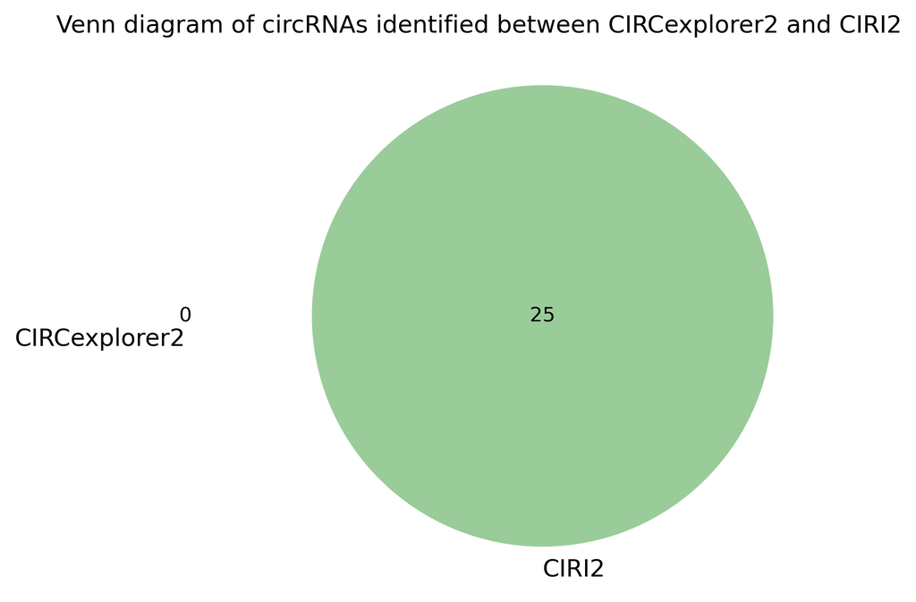

#### Combined circRNA Matrix

| circRNA_ID1 | circRNA_ID2 | circRNA_ID3 | Source | junction_read_counts | CPM | circRNA_type | Strandness |
| --- | --- | --- | --- | --- | --- | --- | --- |
| chr1:117402185\|117414831\|ENSG00000198162.12 | chr1:117402185\|117414831\|MAN1A2 | circRNA1\|MAN1A2 | CIRI2 | 4 | 0.32 | exon | + |
| chr1:117402185\|117420649\|ENSG00000198162.12 | chr1:117402185\|117420649\|MAN1A2 | circRNA2\|MAN1A2 | CIRI2 | 21 | 1.69 | exon | + |
| chr1:172551511\|172570730\|ENSG00000094975.15 | chr1:172551511\|172570730\|SUCO | circRNA1\|SUCO | CIRI2 | 4 | 0.32 | exon | + |
| chr11:34071725\|34076642\|ENSG00000135387.21 | chr11:34071725\|34076642\|CAPRIN1 | circRNA1\|CAPRIN1 | CIRI2 | 4 | 0.32 | exon | + |
| chr11:61437624\|61438113\|ENSG00000256591.5,ENSG00000167985.7 | chr11:61437624\|61438113\|novel | chr11:61437624\|61438113 | CIRI2 | 3 | 0.24 | exon | + |
| chr12:350620\|356537\|ENSG00000073614.13 | chr12:350620\|356537\|KDM5A | circRNA1\|KDM5A | CIRI2 | 4 | 0.32 | exon | - |
| chr14:30923209\|30956242\|ENSG00000196792.12 | chr14:30923209\|30956242\|STRN3 | circRNA1\|STRN3 | CIRI2 | 6 | 0.48 | intron | - |
| chr14:73103191\|73111802\|ENSG00000119707.14 | chr14:73103191\|73111802\|RBM25 | circRNA1\|RBM25 | CIRI2 | 11 | 0.89 | exon | + |
| chr17:8506317\|8509949\|ENSG00000133026.14 | chr17:8506317\|8509949\|MYH10 | circRNA1\|MYH10 | CIRI2 | 9 | 0.72 | exon | - |
| chr17:50743705\|50746702\|ENSG00000108848.16 | chr17:50743705\|50746702\|LUC7L3 | circRNA1\|LUC7L3 | CIRI2 | 7 | 0.56 | exon | + |

[output cut: 15 more lines]

# Step 11: RNA Sequencing Metrics

**Not applicable:** Insert Size Distribution (expected `insert_size_histogram.png$` in `Step_11_RNA_Metrics`)

# Step 15: featureCounts Expression

#### Combined Linear & Circular RNA Expression

**Chart: Expression Analysis Plots**

Example_001_bar_plot_for_top_100_highly_expressed_genes.png

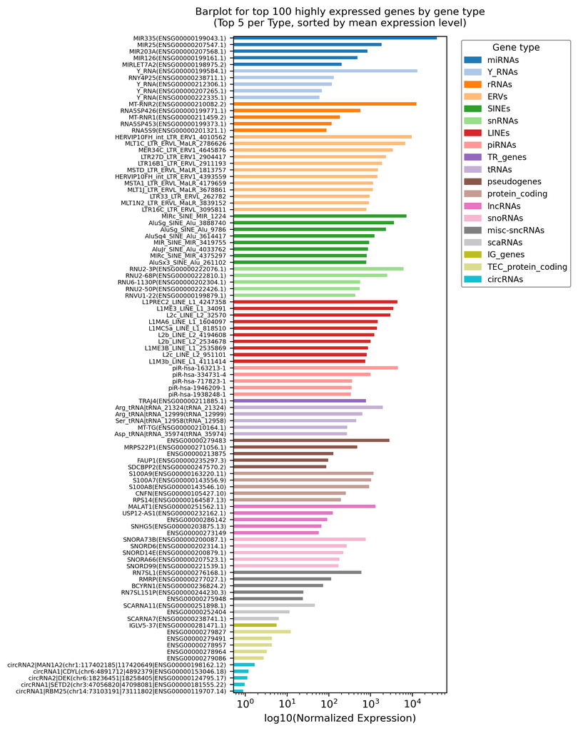

Example_001_RNA_type_composition_1subplot.png

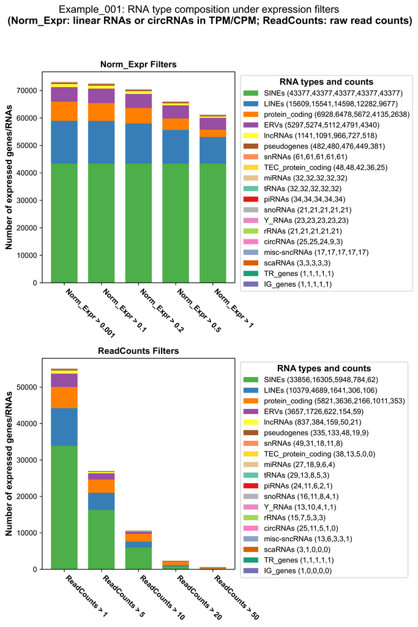

Example_001_RNA_type_composition_20subplots.png

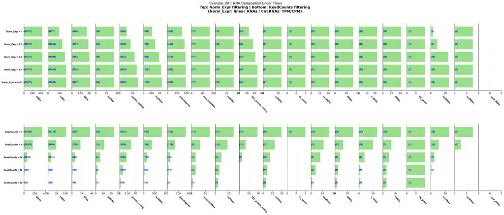

Example_001_RNA_type_composition_2subplots.pdf.png

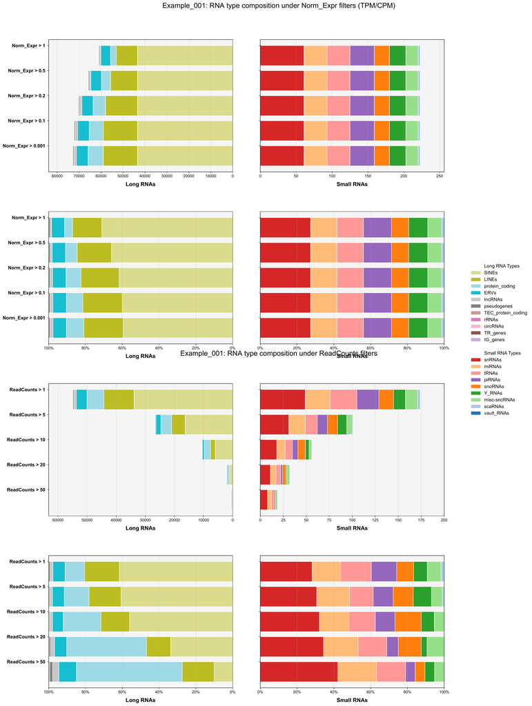

# Step 16: gDNA-Corrected Expression

#### Combined Expression (gDNA Corrected)

**Chart: gDNA-Corrected Expression Plots**

Example_001_bar_plot_for_top_100_highly_expressed_genes.png

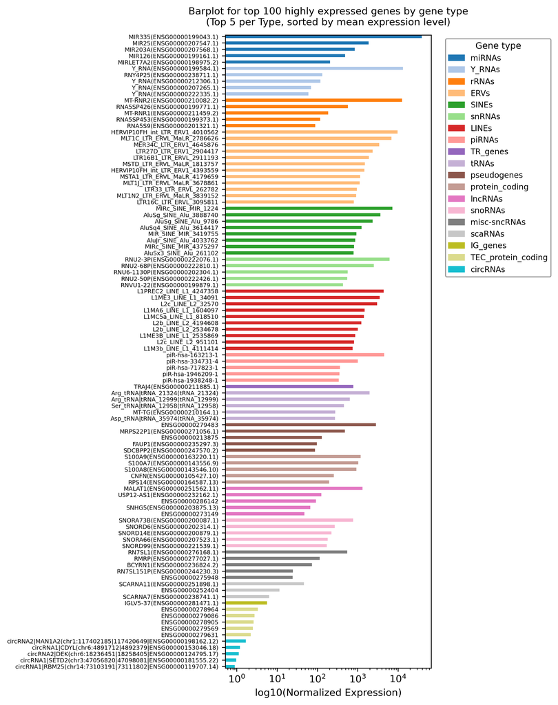

Example_001_RNA_type_composition_1subplot.png

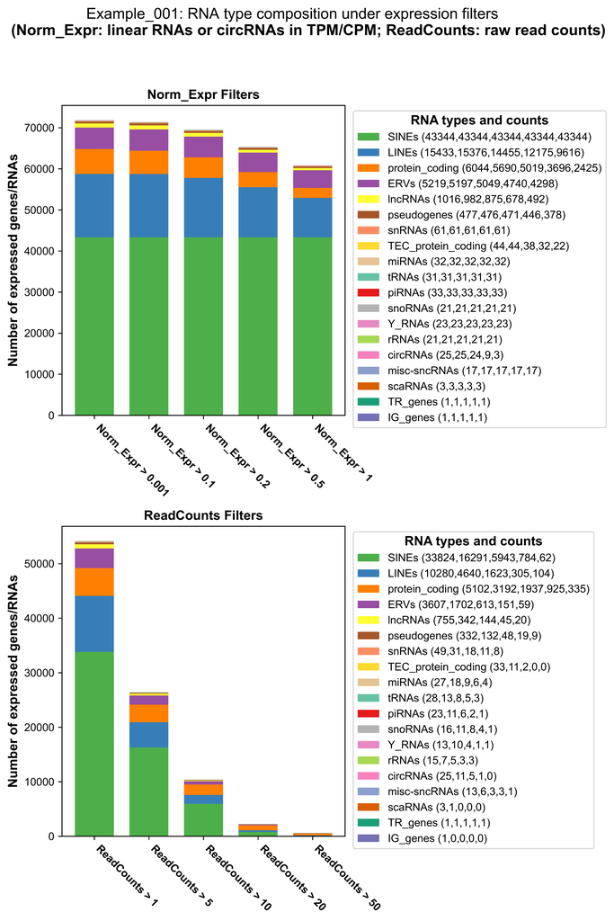

Example_001_RNA_type_composition_20subplots.png

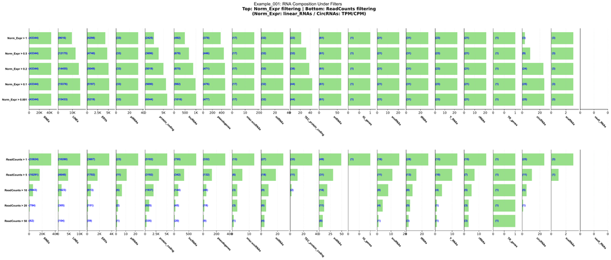

Example_001_RNA_type_composition_2subplots.pdf.png

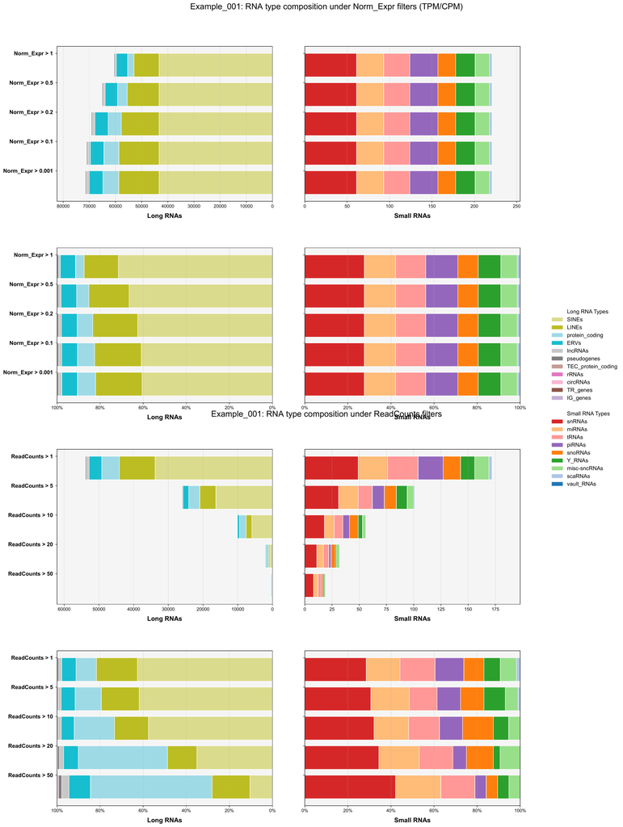

# Step 17: RSEM Expression Quantification

#### Combined Expression (RSEM)

**Chart: RSEM-based Expression Plots**

Example_001_bar_plot_for_top_100_highly_expressed_genes.png

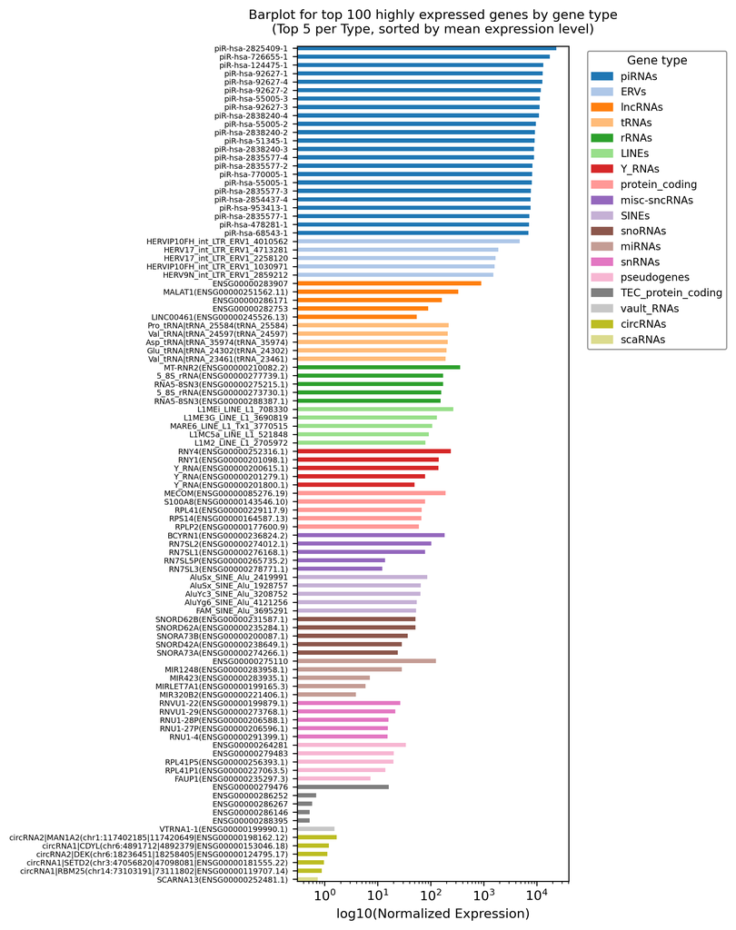

Example_001_RNA_type_composition_1subplot.png

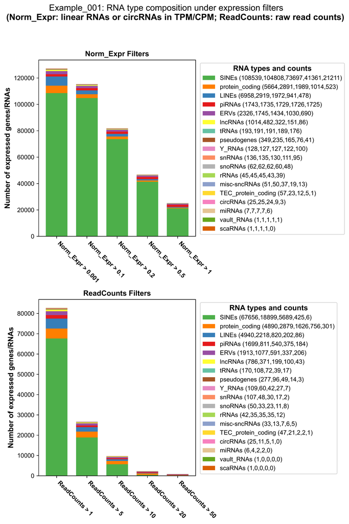

Example_001_RNA_type_composition_20subplots.png

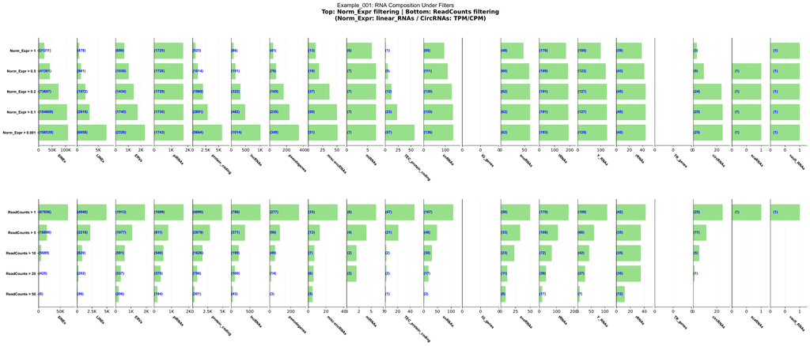

Example_001_RNA_type_composition_2subplots.pdf.png

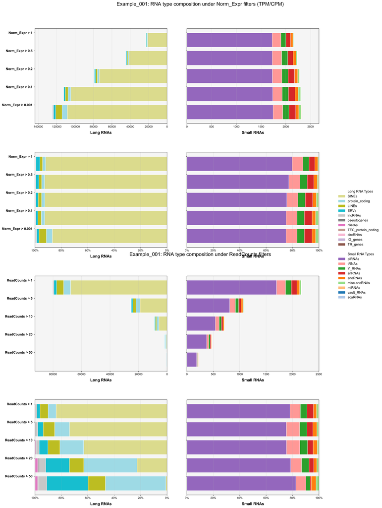